# Practice 7.2: Penalized Regression

```python
import pandas as pd
import numpy as np
from sklearn.pipeline import Pipeline
from sklearn.compose import make_column_selector, ColumnTransformer
from sklearn.preprocessing import StandardScaler, OneHotEncoder, PolynomialFeatures
from sklearn.linear_model import LinearRegression, Ridge, Lasso, ElasticNet
from sklearn.model_selection import train_test_split, cross_val_score, GridSearchCV
from sklearn.metrics import r2_score
```

```python
# Read the data
ames = pd.read_csv("https://www.dropbox.com/scl/fi/g0n5le5p6fr136ggetfsf/AmesHousing.csv?rlkey=jlr9xtz1o6u5rghfo29a5c02f&dl=1")

# Get rid of columns with mostly NaN values
good_cols = ames.isna().sum() < 100
ames = ames.loc[:,good_cols]

# Drop other NAs
ames = ames.dropna()
```

#### Data Cleaning

- Adjust categorical columns to actually be objects instead of numerical data types
- Adjust numerical columns to be numerical data types instead of objects or other data types
- Handle missing data (do not fill with zeroes)
  - We will drop whole columns if they have greater than 100 NAs
  - We will drop individuals rows in the rest of the dataset that have NAs

```python
ames[["Order", "PID"]]
```

|  | Order | PID |
| --- | --- | --- |
| 0 | 1 | 526301100 |
| 1 | 2 | 526350040 |
| 2 | 3 | 526351010 |
| 3 | 4 | 526353030 |
| 4 | 5 | 527105010 |
| ... | ... | ... |
| 2925 | 2926 | 923275080 |
| 2926 | 2927 | 923276100 |
| 2927 | 2928 | 923400125 |
| 2928 | 2929 | 924100070 |
| 2929 | 2930 | 924151050 |

2821 rows × 2 columns

```python
# If there are variables we know we never want to use, we need to explicitly
# drop them so that we can use remainder = "passthrough" in the column
# transformer.

X = ames.drop(["SalePrice", "Order", "PID"], axis = 1)
y = ames["SalePrice"]

ct = ColumnTransformer(
  [
    ("dummify",
    OneHotEncoder(sparse_output = False, handle_unknown="ignore"),
    make_column_selector(dtype_include=object)),
    ("standardize",
    StandardScaler(),
    make_column_selector(dtype_include=np.number))
  ],
  remainder = "passthrough"
)

lr_pipeline_1 = Pipeline(
  [("preprocessing", ct),
  ("linear_regression", LinearRegression())]
)
```

#### Descriptions of new things:

- make_column_selector(dtype_include=object): Just find all the columns where the type is object
- make_column_selector(dtype_include=np.number): Just find all the columns where the type is numeric
- handle_unknown=“ignore” in the OneHotEncoder is happening because there are categorical variables that appear in the test data but they were not seen by the training data
- We drop the Order and PID columns because they are identifier columns, which we always drop before modeling.

```python
cross_val_score(lr_pipeline_1, X, y, cv = 5, scoring = 'r2')
```

```
array([-4.59217770e+20, -1.21723181e+20, -8.37868327e+19, -9.71584476e+20,
       -3.78389822e+20])
```

#### We used so many predictors that we overfit the training data way too much and ended up with terrible predictions

### Ridge Regression

- OLS is too flexible when we have a lot of betas
- Regularization: Change our idea of best betas. We are now going to restrict our definition of a best beta are minimizing a sum of squared residuals while also minimizing the size of the betas themselves
- The ridge penalty added to the sum of squared residuals introduces a new term operating against the other.
- We have to decide how important the residuals being small vs betas being small is. How much restriction λ should we introduce? If λ is zero, we are back to ols, if it is big, we won’t care as much about residuals.

```python
ct = ColumnTransformer(
  [
    ("dummify",
    OneHotEncoder(sparse_output = False, handle_unknown="ignore"),
    make_column_selector(dtype_include=object)),
    ("standardize",
    StandardScaler(),
    make_column_selector(dtype_include=np.number))
  ],
  remainder = "passthrough"
)

ridge_pipeline_1 = Pipeline(
  [("preprocessing", ct),
  ("ridge_regression", Ridge(alpha=1))]
)
```

```python
cross_val_score(ridge_pipeline_1, X, y, cv = 5, scoring = 'r2')
```

```
array([0.8983804 , 0.91749817, 0.79251623, 0.78248152, 0.91492025])
```

### Practice Activity: Ridge Regression

Fit the model on the whole dataset and get the coefficients. Make a plot of these coefficients compared to the ones from ordinary linear regression.

```python
fitted_lr_pipeline = lr_pipeline_1.fit(X, y)
fitted_ridge_pipeline = ridge_pipeline_1.fit(X, y)
```

```python
lr_coefs = fitted_lr_pipeline.named_steps["linear_regression"].coef_
ridge_coefs = fitted_ridge_pipeline.named_steps["ridge_regression"].coef_
```

```python
coefs_df = pd.DataFrame({"LinearRegressionCoefs" : lr_coefs,
                         "RidgeRegressionCoefs" : ridge_coefs})
```

```python
from plotnine import ggplot, aes, geom_point
```

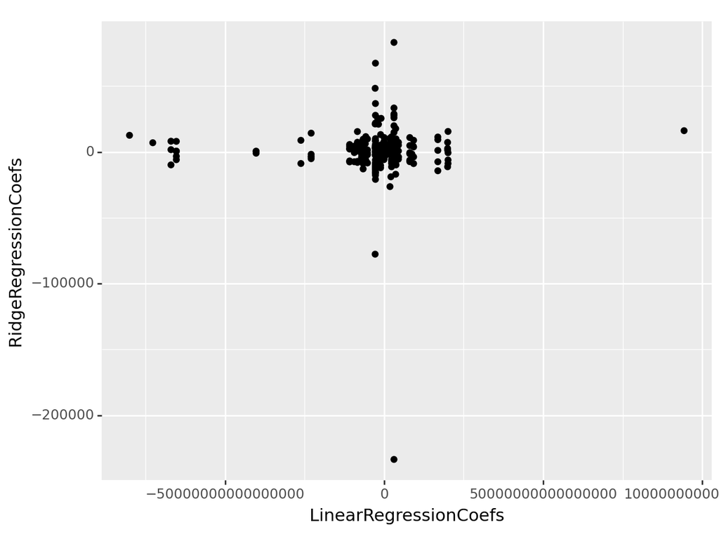

```
<Figure Size: (640 x 480)>
```

```python
(ggplot(coefs_df, aes(x="LinearRegressionCoefs", y="RidgeRegressionCoefs"))
+ geom_point()
)
```

### Practice Activity: Tuning

- We don’t really know without trying many possibilities for λ what the best value is.
- λ is a hyperparameter, which means we can perform tuning on it.

Using the same pipeline as previously, perform tuning on λ

You should always try λ values on a log scale; that is, don’t use [1,2,3,4]; instead use something like [0.001, 0.01, 0.1, 1, 10]

```python
ct = ColumnTransformer(
  [
    ("dummify",
    OneHotEncoder(sparse_output = False, handle_unknown="ignore"),
    make_column_selector(dtype_include=object)),
    ("standardize",
    StandardScaler(),
    make_column_selector(dtype_include=np.number))
  ],
  remainder = "passthrough"
)

ridge_pipeline_grid = Pipeline(
  [("preprocessing", ct),
  ("ridge_regression", Ridge())]
)
```

```python
alphas = {"ridge_regression__alpha" : [0.1, 1, 10, 100, 1000]}
gscv = GridSearchCV(ridge_pipeline_grid, alphas, cv = 5, scoring="r2")
```

```python
gscv_fitted = gscv.fit(X, y)
```

```python
ridge_df = pd.DataFrame(data = {"alphas": [0.1, 1, 10, 100, 1000], "scores": gscv_fitted.cv_results_['mean_test_score']})
```

```python
ridge_df.sort_values(by=["scores"], ascending=False)
```

|  | alphas | scores |
| --- | --- | --- |
| 2 | 10.0 | 0.863355 |
| 1 | 1.0 | 0.861159 |
| 3 | 100.0 | 0.857129 |
| 0 | 0.1 | 0.855423 |
| 4 | 1000.0 | 0.832971 |

```python
# Alpha 10 Ridge:
ct = ColumnTransformer(
  [
    ("dummify",
    OneHotEncoder(sparse_output = False, handle_unknown="ignore"),
    make_column_selector(dtype_include=object)),
    ("standardize",
    StandardScaler(),
    make_column_selector(dtype_include=np.number))
  ],
  remainder = "passthrough"
)

ridge_pipeline_10 = Pipeline(
  [("preprocessing", ct),
  ("ridge_regression", Ridge(10))]
)
```

```python
fitted_ridge_pipeline_10 = ridge_pipeline_10.fit(X, y)
```

```python
coefs_df["Ridge_10"] = fitted_ridge_pipeline_10["ridge_regression"].coef_
```

#### Lasso Regression

- Now we want to use an absolute value instead of a squared value for our beta penalizer.
- Ridge Regression will result in coefficients that are generally *smaller* than OLS, Lasso will cause some coefficients to be *equal* to zero, which is essentially **automatic feature selection**.

### Practice Activity: Lasso

Create a LASSO pipeline, and tune λ.

Fit your best model on the full Ames data, and compare the coefficients to Ridge and OLS

```python
ct = ColumnTransformer(
  [
    ("dummify",
    OneHotEncoder(sparse_output = False, handle_unknown="ignore"),
    make_column_selector(dtype_include=object)),
    ("standardize",
    StandardScaler(),
    make_column_selector(dtype_include=np.number))
  ],
  remainder = "passthrough"
)

lasso_pipeline_grid = Pipeline(
  [("preprocessing", ct),
  ("lasso_regression", Lasso())]
)
```

```python
alphas = {"lasso_regression__alpha" : [1, 10, 100, 1000]}
gscv = GridSearchCV(lasso_pipeline_grid, alphas, cv = 5, scoring="r2")
```

```python
gscv_fitted = gscv.fit(X, y)
```

```python
lasso_df = pd.DataFrame(data = {"alphas": [1, 10, 100, 1000], "scores": gscv_fitted.cv_results_['mean_test_score']})
```

```python
lasso_df.sort_values(by=["scores"], ascending=False)
```

|  | alphas | scores |
| --- | --- | --- |
| 2 | 100 | 0.866170 |
| 1 | 10 | 0.859495 |
| 0 | 1 | 0.855890 |
| 3 | 1000 | 0.839606 |

```python
# Alpha 100 Ridge
ct = ColumnTransformer(
  [
    ("dummify",
    OneHotEncoder(sparse_output = False, handle_unknown="ignore"),
    make_column_selector(dtype_include=object)),
    ("standardize",
    StandardScaler(),
    make_column_selector(dtype_include=np.number))
  ],
  remainder = "passthrough"
)

lasso_pipeline_100 = Pipeline(
  [("preprocessing", ct),
  ("lasso_regression", Lasso(alpha=100))]
)
```

```python
fitted_lasso_pipeline_100 = lasso_pipeline_100.fit(X, y)
```

```python
coefs_df["Lasso_100"] = fitted_lasso_pipeline_100["lasso_regression"].coef_
```

```python
coefs = coefs_df.reset_index()
```

```python
coefs
```

|  | index | LinearRegressionCoefs | RidgeRegressionCoefs | Ridge_10 | Lasso_100 |
| --- | --- | --- | --- | --- | --- |
| 0 | 0 | -6.831270e+13 | -5740.055372 | -4850.945920 | -0.000000 |
| 1 | 1 | -6.831270e+13 | 1511.928887 | 2066.389264 | 0.000000 |
| 2 | 2 | -6.831270e+13 | -5809.704488 | -1258.862909 | -0.000000 |
| 3 | 3 | -6.831270e+13 | 7676.327583 | 4447.225780 | 0.000000 |
| 4 | 4 | -6.831270e+13 | 3215.393618 | 2348.719094 | 211.722517 |
| ... | ... | ... | ... | ... | ... |
| 254 | 254 | 2.708000e+03 | 2937.762099 | 3130.514090 | 2858.436687 |
| 255 | 255 | 2.714000e+03 | 1377.194605 | 465.334450 | 792.157582 |
| 256 | 256 | -5.204000e+03 | -4485.971545 | -4188.491022 | -4361.734206 |
| 257 | 257 | -6.960000e+02 | -674.189275 | -606.042386 | -564.805646 |
| 258 | 258 | -6.880000e+02 | -905.496080 | -1014.435494 | -767.096168 |

259 rows × 5 columns

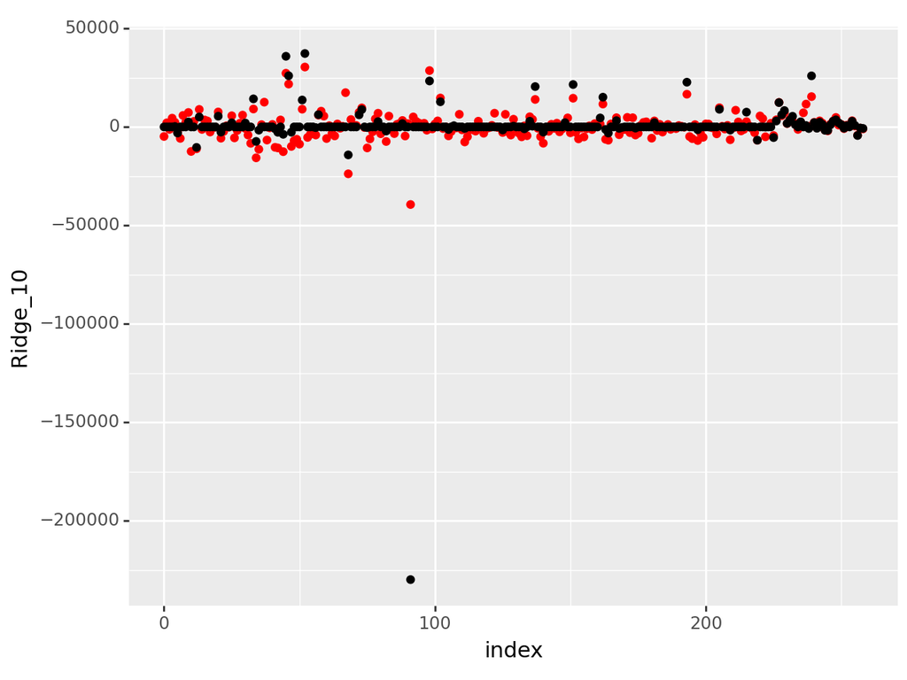

```
<Figure Size: (640 x 480)>
```

```python
(ggplot(coefs, aes(x="index"))
+ geom_point(aes(y="Ridge_10"), color="red")
+ geom_point(aes(y="Lasso_100")))
```

#### Practice Activity: Elastic Net

- We can add both ridge and lasso penalties to our model.
- We can create an elastic net pipeline, and tune λ and α
- α is actually called l1_ratio in scikit learn, and λ is called alpha.

```python
# ElasticNet

ct = ColumnTransformer(
  [
    ("dummify",
    OneHotEncoder(sparse_output = False, handle_unknown="ignore"),
    make_column_selector(dtype_include=object)),
    ("standardize",
    StandardScaler(),
    make_column_selector(dtype_include=np.number))
  ],
  remainder = "passthrough"
)

elastic_net = Pipeline(
  [("preprocessing", ct),
  ("elastic_net", ElasticNet())]
)
```

```python
alphas_l1_ratios = {"elastic_net__alpha" : [0.01, 0.1, 1, 10],
                    "elastic_net__l1_ratio" : [0.25, 0.5, 0.75]}
gscv = GridSearchCV(elastic_net, alphas_l1_ratios, cv = 5, scoring="r2")
```

```python
gscv_fitted = gscv.fit(X, y)
```

```python
final_results = pd.DataFrame(gscv_fitted.cv_results_)[["param_elastic_net__alpha", "param_elastic_net__l1_ratio", "mean_test_score"]]
final_results.sort_values(by=["mean_test_score"], ascending=False)
```

|  | param_elastic_net__alpha | param_elastic_net__l1_ratio | mean_test_score |
| --- | --- | --- | --- |
| 1 | 0.01 | 0.5 | 0.863342 |
| 2 | 0.01 | 0.75 | 0.863180 |
| 0 | 0.01 | 0.25 | 0.863116 |
| 5 | 0.1 | 0.75 | 0.860058 |
| 4 | 0.1 | 0.5 | 0.856389 |
| 3 | 0.1 | 0.25 | 0.853601 |
| 8 | 1 | 0.75 | 0.841823 |
| 7 | 1 | 0.5 | 0.830616 |
| 6 | 1 | 0.25 | 0.820963 |
| 11 | 10 | 0.75 | 0.758694 |
| 10 | 10 | 0.5 | 0.673887 |
| 9 | 10 | 0.25 | 0.599899 |

```python
# Final elastic net

ct = ColumnTransformer(
  [
    ("dummify",
    OneHotEncoder(sparse_output = False, handle_unknown="ignore"),
    make_column_selector(dtype_include=object)),
    ("standardize",
    StandardScaler(),
    make_column_selector(dtype_include=np.number))
  ],
  remainder = "passthrough"
)

elastic_net = Pipeline(
  [("preprocessing", ct),
  ("elastic_net", ElasticNet(alpha=0.01, l1_ratio=0.5))]
)

fitted_elastic_net = elastic_net.fit(X, y)
```

```python
coefs["Elastic_Net"] = fitted_elastic_net["elastic_net"].coef_
```

```python
coefs
```

|  | index | LinearRegressionCoefs | RidgeRegressionCoefs | Ridge_10 | Lasso_100 | Elastic_Net |
| --- | --- | --- | --- | --- | --- | --- |
| 0 | 0 | -6.831270e+13 | -5740.055372 | -4850.945920 | -0.000000 | -4297.528602 |
| 1 | 1 | -6.831270e+13 | 1511.928887 | 2066.389264 | 0.000000 | 2260.653545 |
| 2 | 2 | -6.831270e+13 | -5809.704488 | -1258.862909 | -0.000000 | -937.596512 |
| 3 | 3 | -6.831270e+13 | 7676.327583 | 4447.225780 | 0.000000 | 3697.225050 |
| 4 | 4 | -6.831270e+13 | 3215.393618 | 2348.719094 | 211.722517 | 2363.945791 |
| ... | ... | ... | ... | ... | ... | ... |
| 254 | 254 | 2.708000e+03 | 2937.762099 | 3130.514090 | 2858.436687 | 3147.699891 |
| 255 | 255 | 2.714000e+03 | 1377.194605 | 465.334450 | 792.157582 | 389.769478 |
| 256 | 256 | -5.204000e+03 | -4485.971545 | -4188.491022 | -4361.734206 | -4210.617314 |
| 257 | 257 | -6.960000e+02 | -674.189275 | -606.042386 | -564.805646 | -584.727997 |
| 258 | 258 | -6.880000e+02 | -905.496080 | -1014.435494 | -767.096168 | -1012.531461 |

259 rows × 6 columns

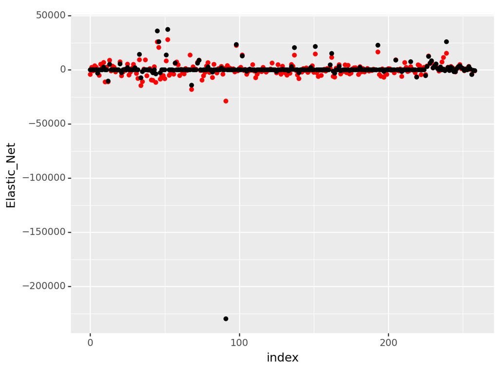

```
<Figure Size: (640 x 480)>
```

```python
(ggplot(coefs, aes(x="index"))
+ geom_point(aes(y="Elastic_Net"), color="red")
+ geom_point(aes(y="Lasso_100")))
```

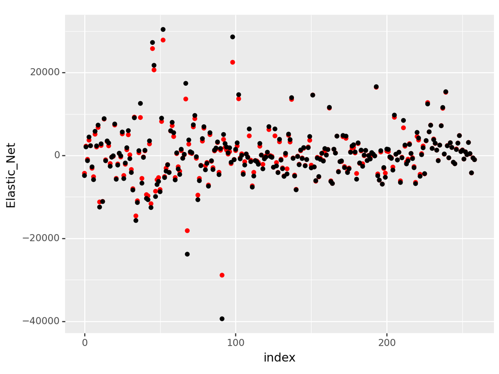

```
<Figure Size: (640 x 480)>
```

```python
(ggplot(coefs, aes(x="index"))
+ geom_point(aes(y="Elastic_Net"), color="red")
+ geom_point(aes(y="Ridge_10")))
```

##### Coefficient Interpretation

- The optimized elastic net with alpha=0.01 and l1_ratio=0.5 has coefficients spaced out more than the lasso model with alpha=100.
- The optimized elastic net with alpha=0.01 and l1_ratio=0.5 has coefficients which are extremely close to all the ridge regression model. This is interesting because the l1_ratio is 0.5, so I would have expected something more in between lasso and ridge instead of so close to ridge.”